# Coin Experiment

## Experiment

Number of heads

[figure not shown]

## Emperical Cycle

- **Observation** Patiënt is showing post traumatic symptoms
- **Induction** Intherapy works
- **Deduction** $H_0$: P: fair coin → C: patiënt is balanced
- **Deduction** $H_A$: P: Unfair coin → C: patiënt is unbalanced
- **Deduction** $H_A$: P: data $\neq$ EV → C: is unbalanced
- **Testing** Choose $\alpha$ and Power
- **Evaluation** Make a decision

## Nul distribution

Let’s analyse the null distribution of the results.

[interactive chart not shown]

## Binomial distribution

$${n\choose k}p^k(1-p)^{n-k} \\
{n\choose k} = \frac{n!}{k!(n-k)!}$$

With values:

```r
n = 10   # Sample size
k = 0:10 # Discrete probability space
p = .5   # Probability of head
```

## Probabilities

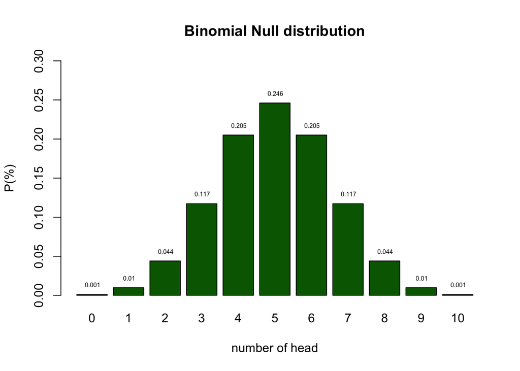

## Testing

I landed 2 times head. Can we conclude that the therapy worked?

> As you can see from the distribution of healthy coins, we cannot conclude that by definition.

> What we can do is indicate how rare 2 is in a healthy population.

> We can see that a percentage of 5% is very rare.

## Testing

- Based on the null distribution we can see that the expected value (EV is 5.)
- We can now define the $H_0$ hypothesis: $H_0 = 5$
- What is the alternative hypothesis?
- The alternative hypothesis describes a situation where the therapy worked.
- We could say that the alternative hypothesis is not 5.
- $H_A \ne 5$
- We could also formulate our $H_0$ and $H_A$ more abstract:
- $H_0:$ the patient is balenced
- $H_A:$ the patient is unbalenced
- What criterium should we use to conclude that one would be unbalenced?
- In the social sciences this $\alpha$ criteria is often 5%.
- I tossed 2 times head. That is more frequent than 5%.
- Therefore, we conclude that our patient is probably healthy but we can never be sure.
- My coin could still be part of the unbalenced population.

## Alternative Distribution

But we have no clue of what this distribution could look like.

For now let’s assume the probability of landing heads for my coin is .25

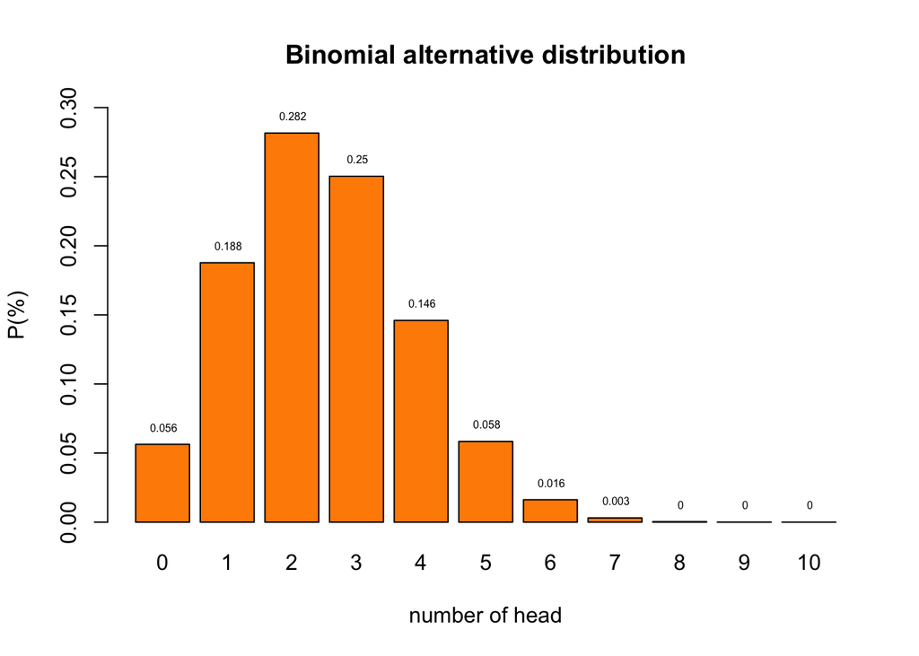

## $H_0$ and $H_A$ distribution

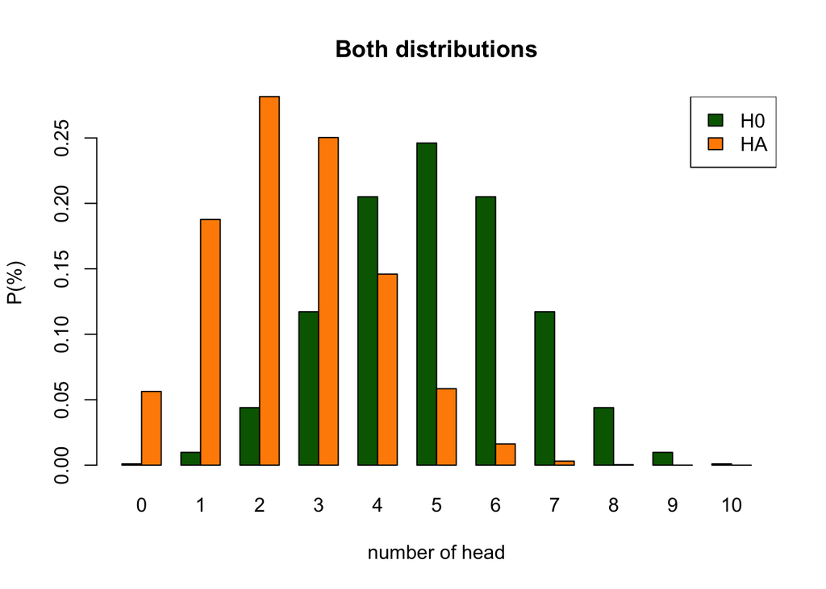

## Power and more

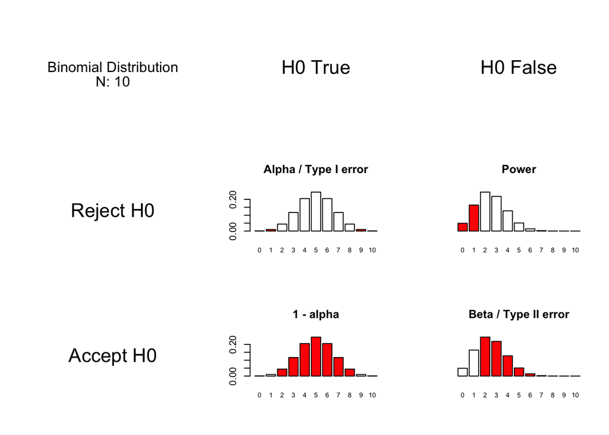